# Pre-harvest hydroponic microbiome

manuscript analysis and figures

Michael DJ Lynch, PhD

2022-09-15

## Hydroponic Microbiome

**Preprint**: Lynch, MDJ, Co, R, Cheng, J, and Charles, TC. 2022. Analysis of the pre-harvest bacterial and eukaryotic hydroponic microbiome.

This repository contains the processed microbiome marker data and analysis notebook for the manusript *Analysis of the pre-harvest bacterial and eukaryotic hydroponic microbiome*.

## alpha-diversity

### Bacteria and Archaea (16S rRNA)

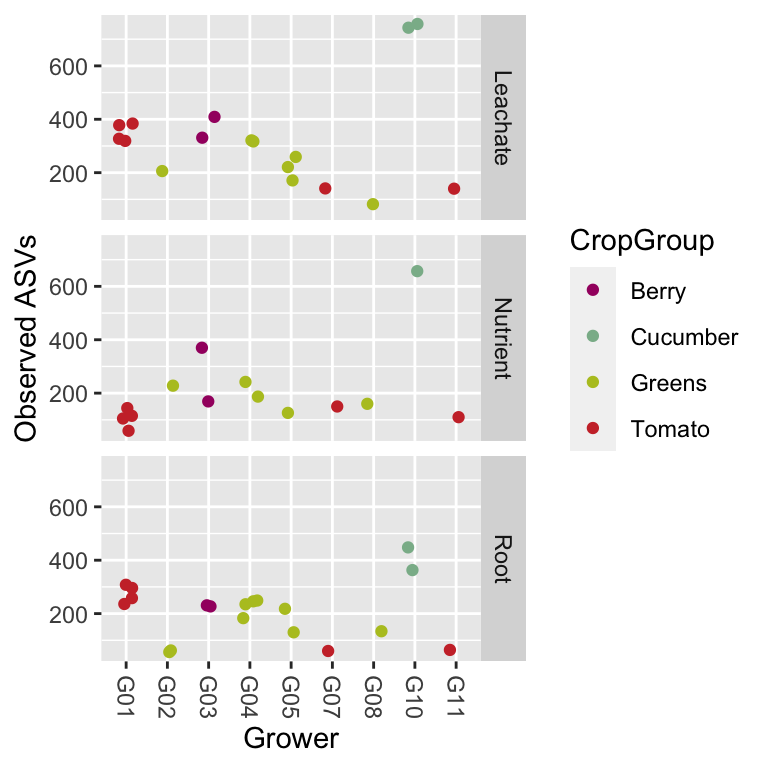

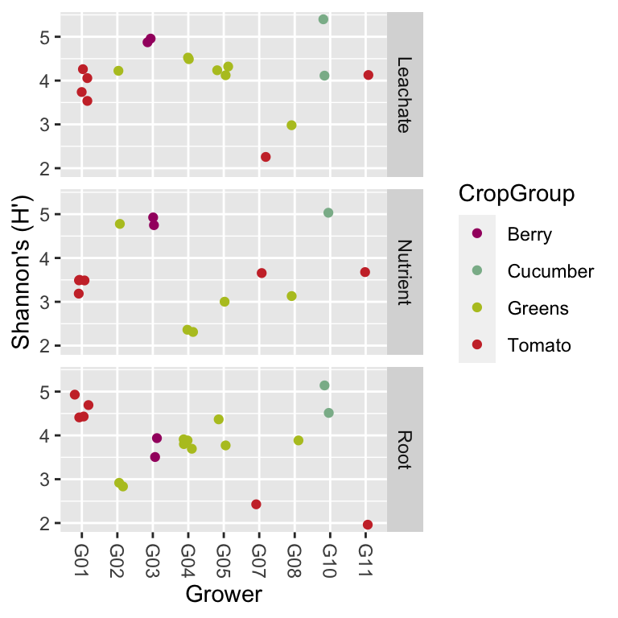

### General Eukaryotes (18S rRNA)

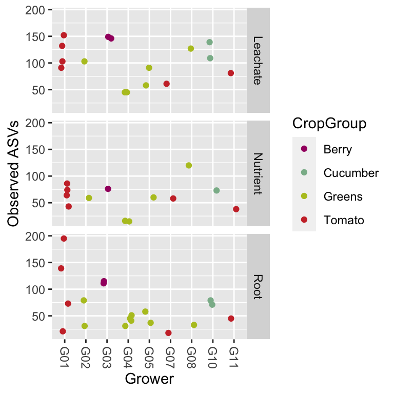

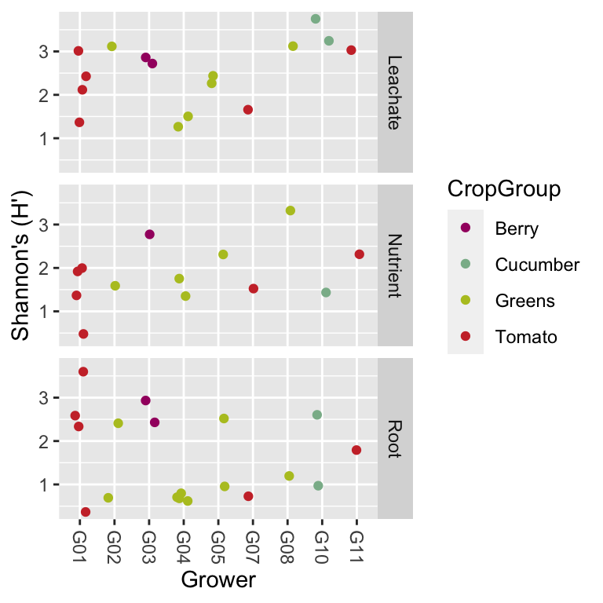

### Fungi (ITS)

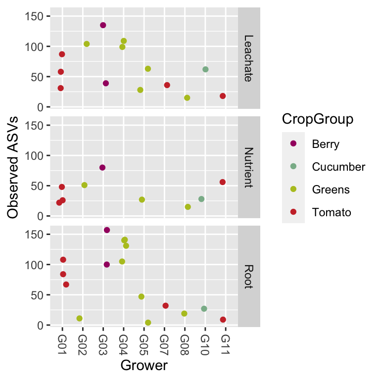

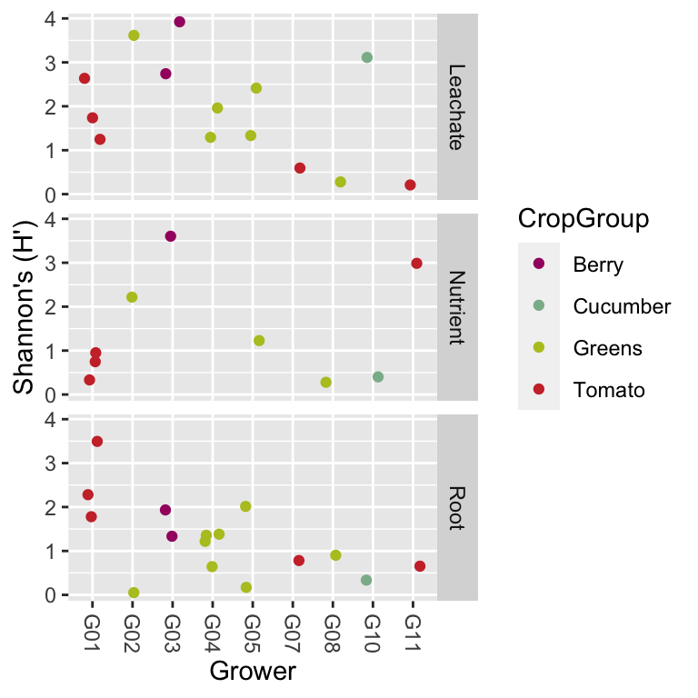

Notable trends:

1. Tomatoes tend to be pretty low in richness and diversity (G07 and G11), but G01 was higher.
2. Cucumbers and berries have high diversity and richness, although with only a single grower it is hard to establish this as a crop effect rather than a grower effect.

## Taxonomic Composition

### Taxonomic heatmaps

Investigating the taxonomic trends in teh top 100 ASVs for each marker gene.

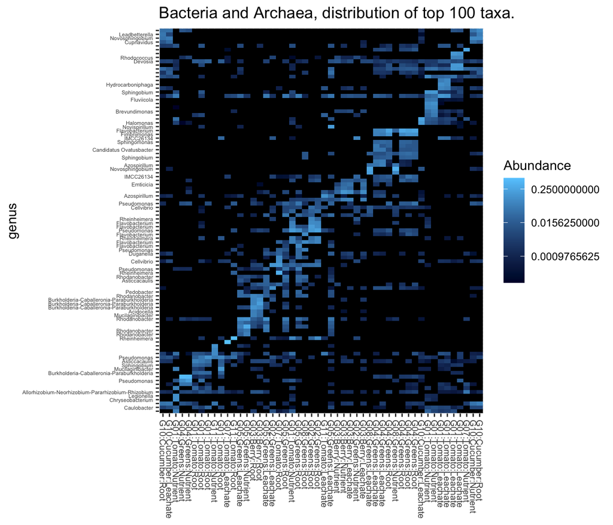

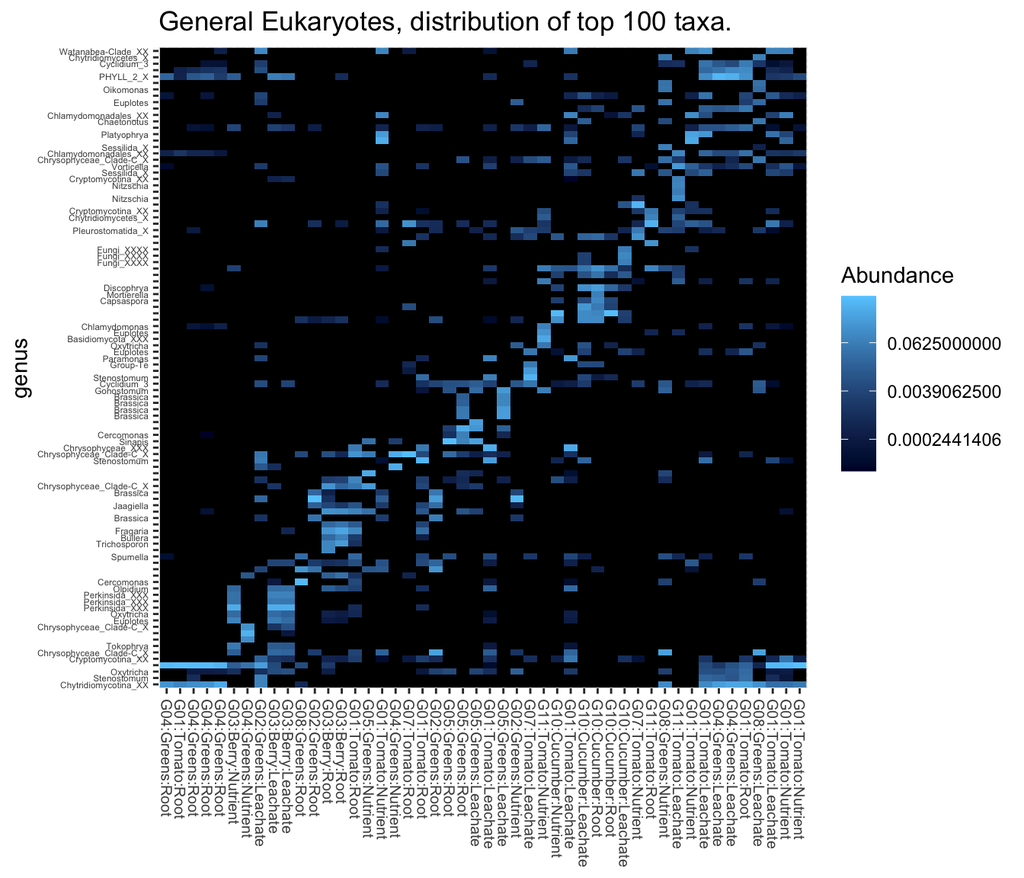

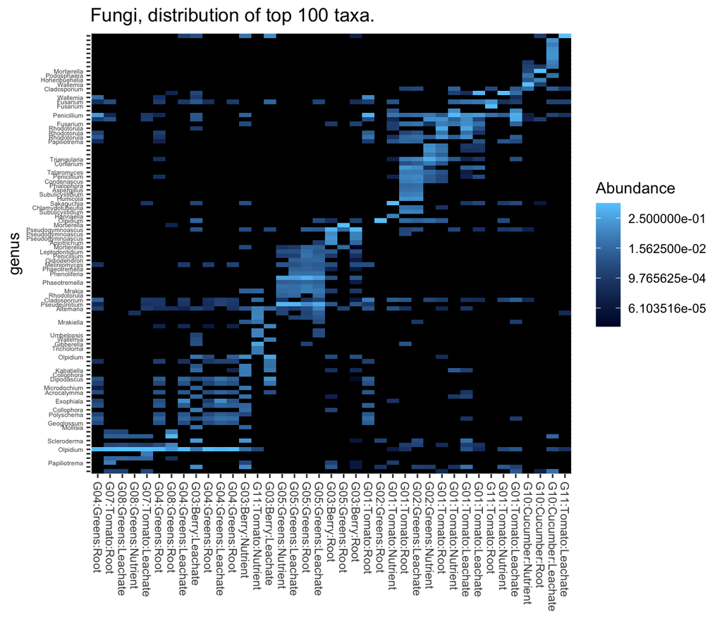

### Key taxa

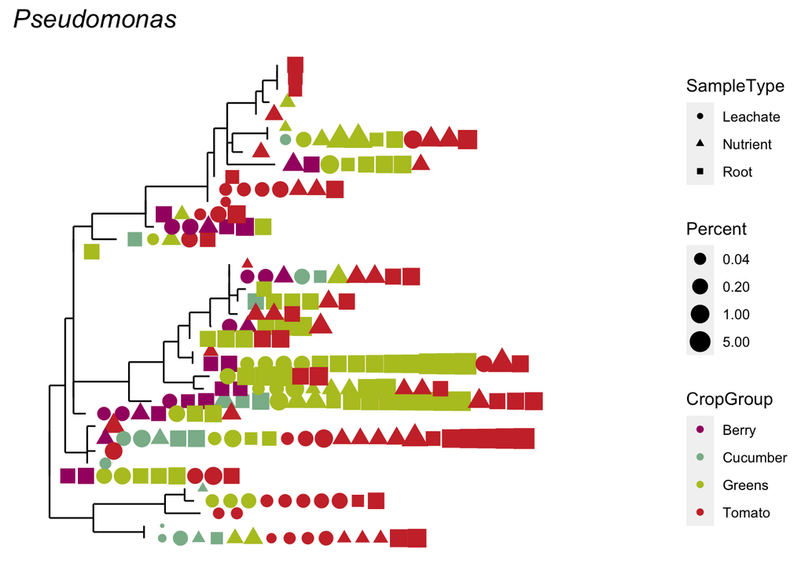

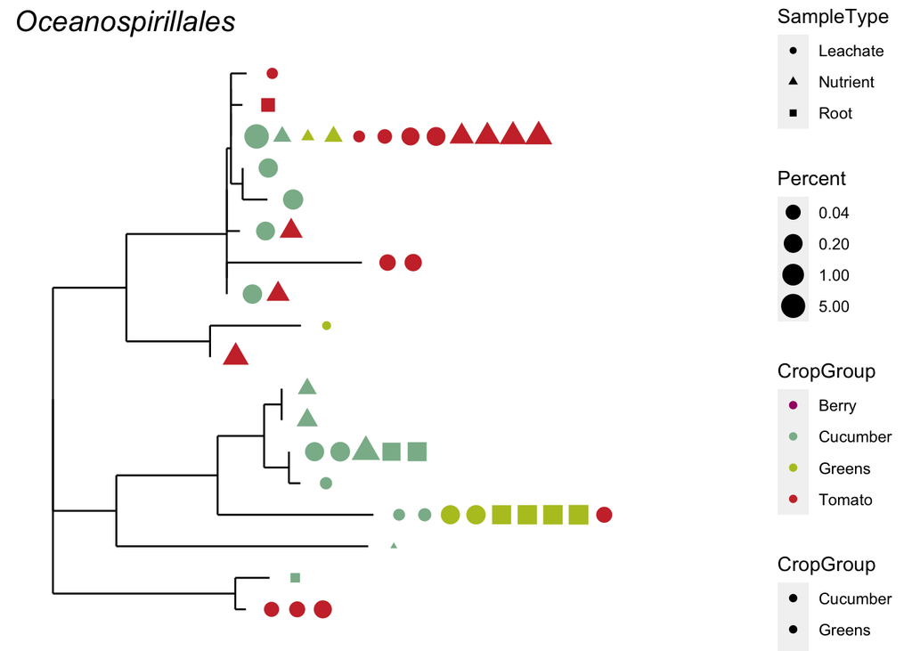

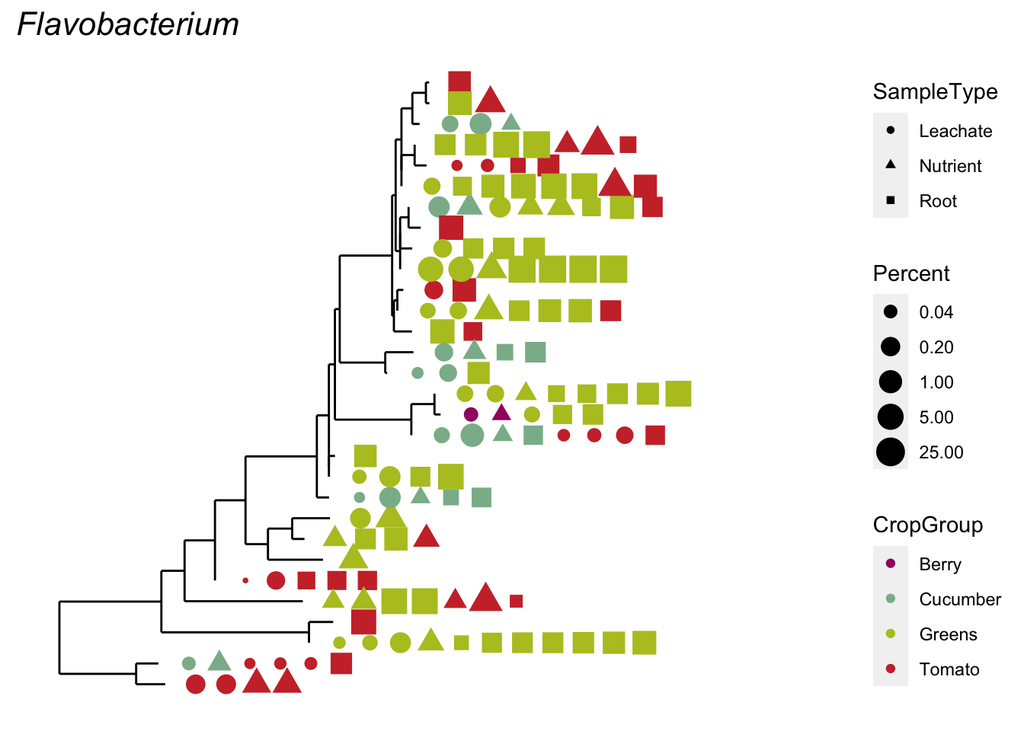

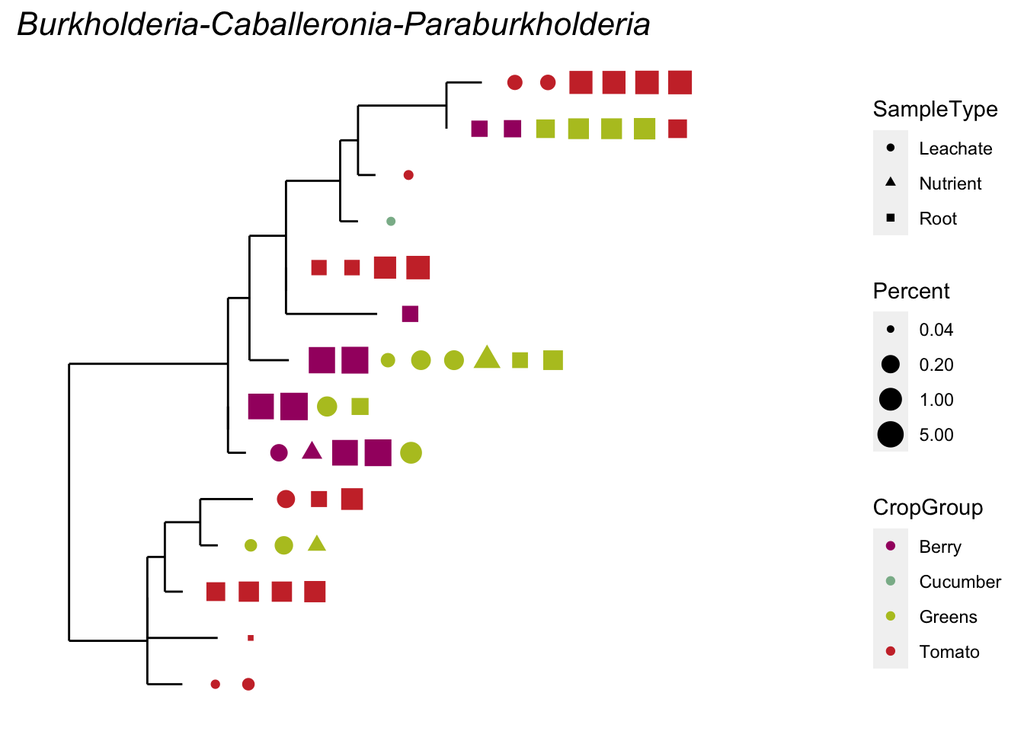

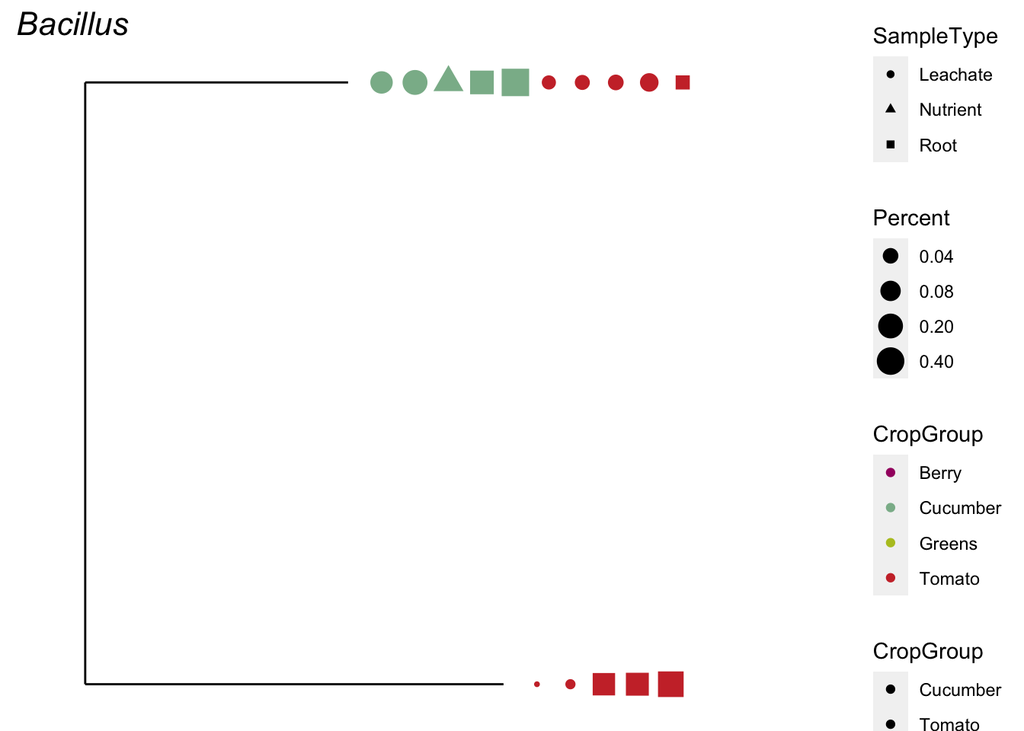

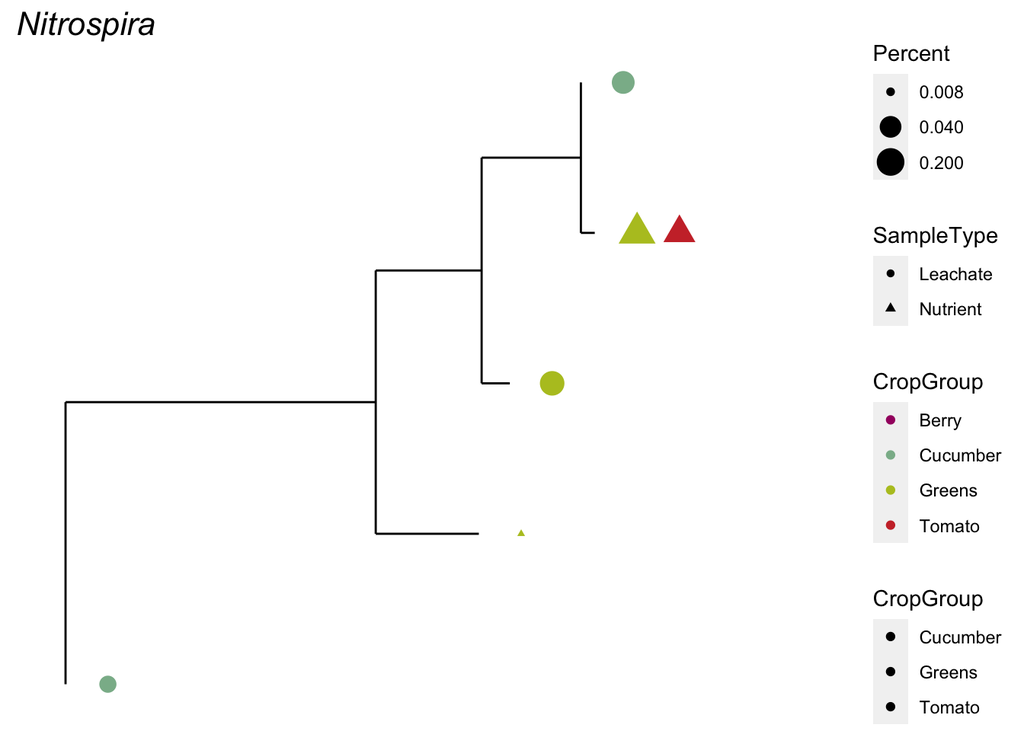

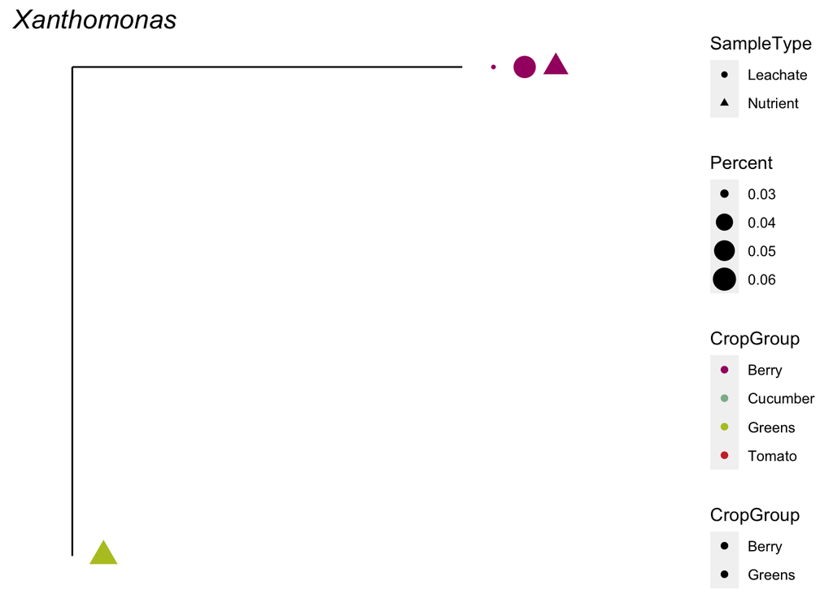

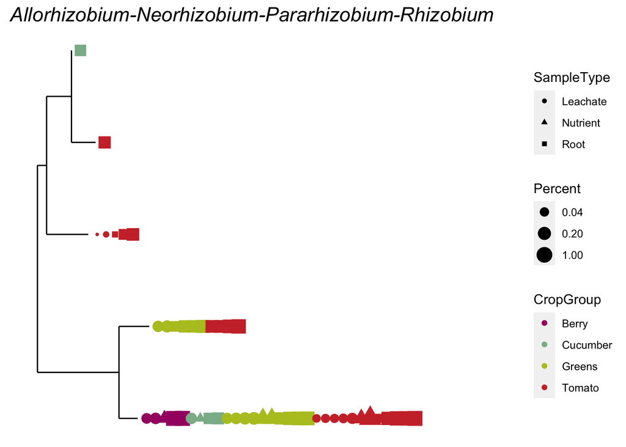

## beta-diversity

Included here are the (A) sample ordinations and (B) sample ordinations with positions of top ten most abundant ASVs (amplified sequence variants).

### Bacteria and Archaea (16S rRNA)

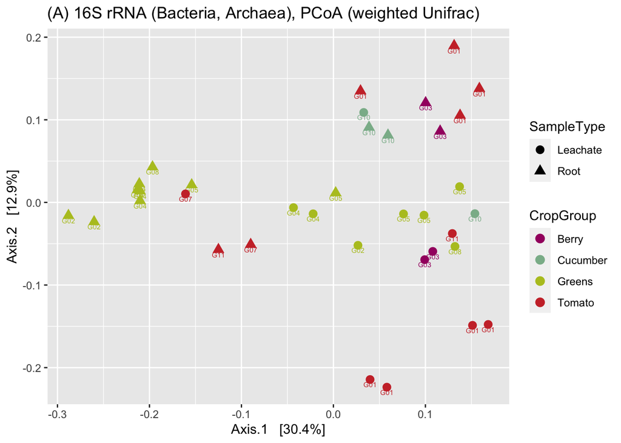

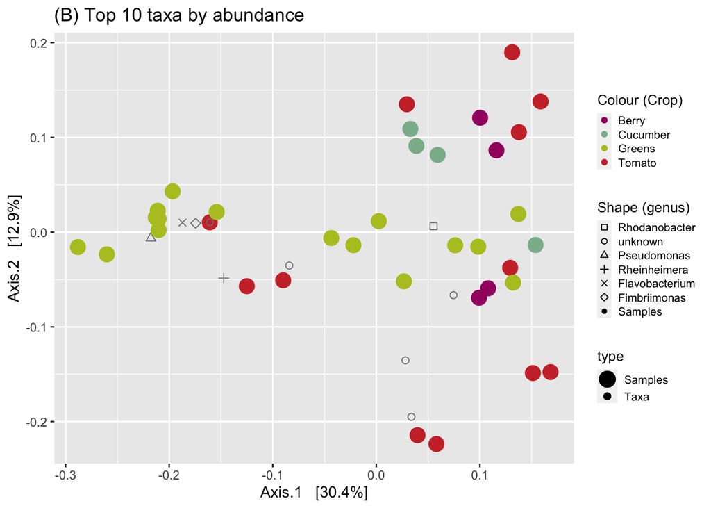

### General eukaryotes (18S rRNA)

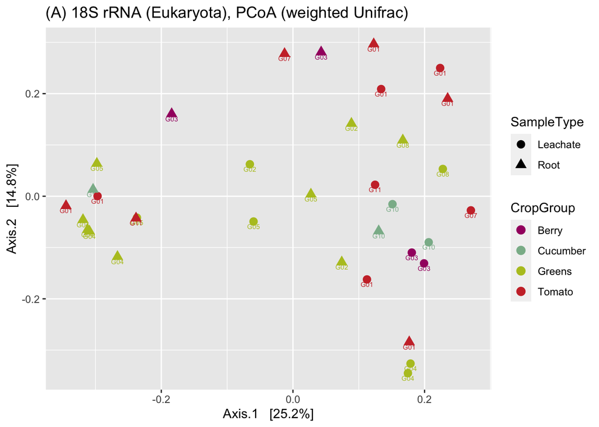

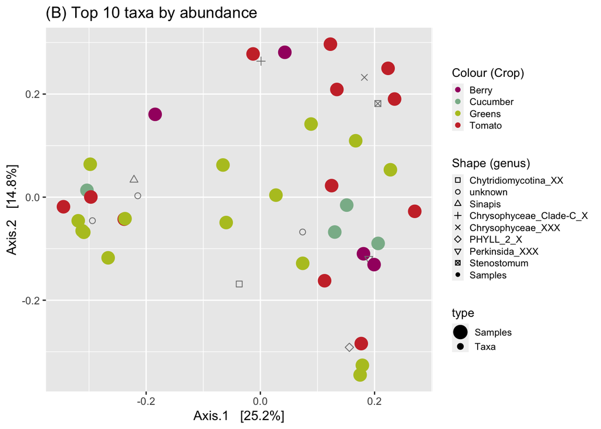

### Fungi (ITS)

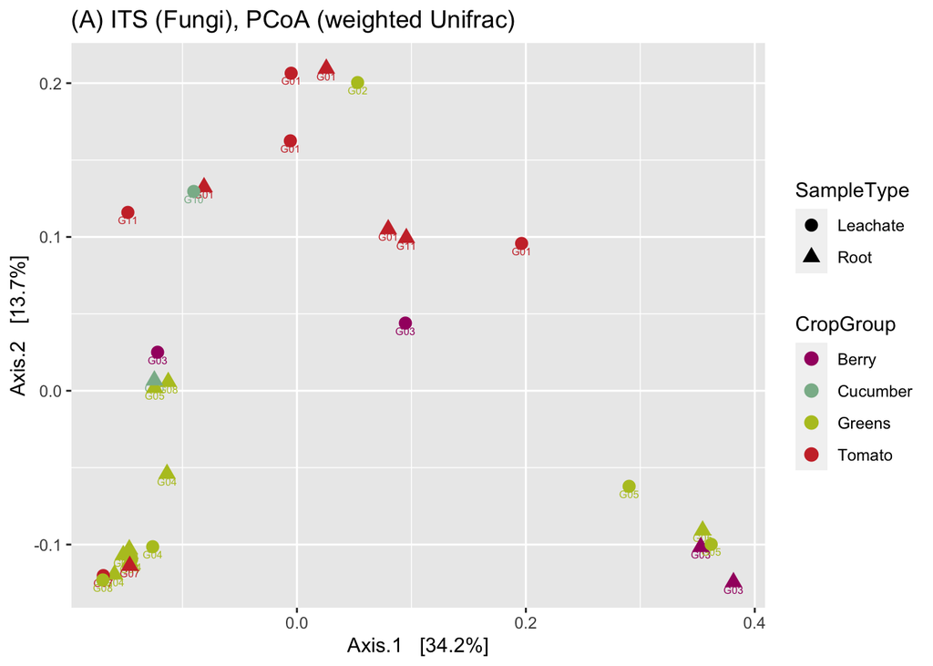

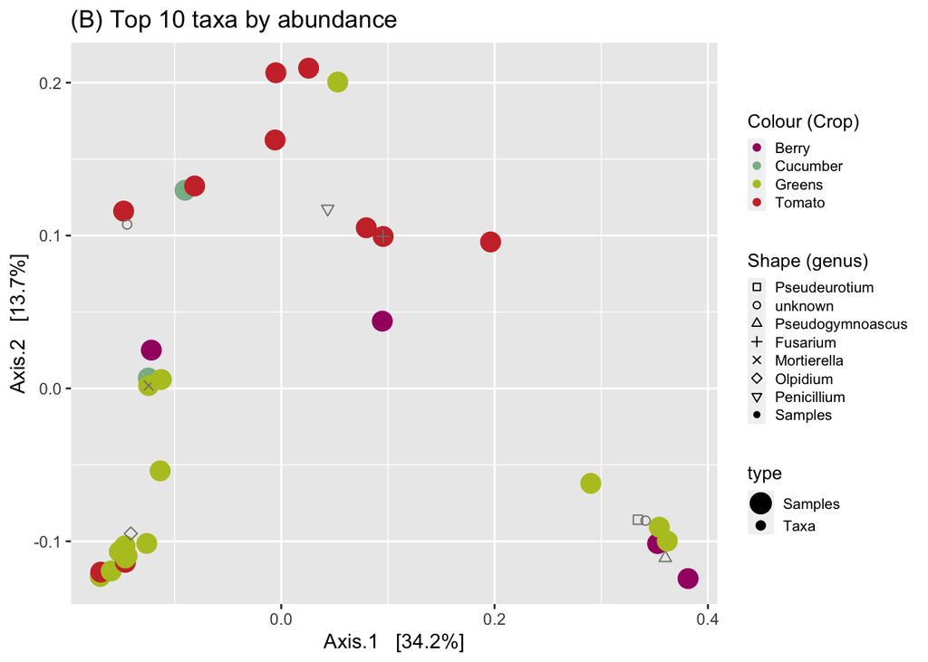